# Visualisierung von Zeitreihen mit ggplot

Manfred Brill

# 1 Ein Beispiel aus Benesch

Der Datensatz enthält Angaben über die Niederschlagswerte in Dakar und Wien und ist dem Buch von Benesch (Benesch 2013) entnommen. Der Datensatz wird zum Beispiel als Motivation für die Einführung von Streuungsparametern verwendet.

```r
# Code aus RStudio <<Import Dataset>>
daten <- read_delim("data/niederschlag.csv",
    ";", escape_double = FALSE, locale = locale(date_names = "de",
        decimal_mark = ","), trim_ws = TRUE)
daten$Monat <- factor(daten$Monat)
```

Der Datensatz enthält pro Monat je einen Wert für Dakar und Wien. Die Werte sind in entsprechenden Spalten enthalten. Tabelle 1 zeigt die eingelesenen werte.

Tabelle 1: Niederschlagswerte in den Städten Wien und Dakar in mm

| Monat | Wien | Dakar |
| --- | --- | --- |
| Januar | 37.5 | 1.0 |
| Februar | 36.8 | 1.5 |
| Maerz | 45.0 | 0.1 |
| April | 51.7 | 0.1 |
| Mai | 68.0 | 0.8 |
| Juni | 70.8 | 13.4 |
| Juli | 75.6 | 75.2 |
| August | 66.6 | 215.3 |
| September | 48.7 | 145.2 |
| Oktober | 49.4 | 42.3 |
| November | 48.4 | 2.5 |
| Dezember | 46.2 | 4.0 |

# 2 Visualisierung von Zeitreihen

Für die Visualisierung von Zeitreihen mit einem Polygonzug verwenden wir *geom_line*, um die einzelnen Punkte ebenfalls darzustellen setzen wir zusätzlich *geom_point* ein. In R gibt es ein Array *month.abb* mit englischen Abkürzungen für die Monatsnamen. Wir möchten hier deutsche Beschriftungen, also besetzen wir selbst ein Feld. Diese Abkürzungen bauen wir mit *scale_x_continous* in die Grafik ein.

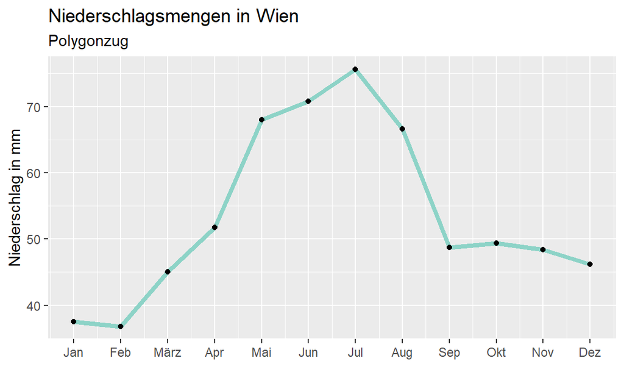

```r
xV <- c(1,2,3,4,5,6,7,8,9,10,11,12)
yV <- c(1,3,2,5,4,3,5,4,3,11,10,12)
myMonths <- c("Jan", "Feb", "März",
              "Apr", "Mai", "Jun",
              "Jul", "Aug", "Sep",
              "Okt", "Nov", "Dez")

daten$months <- xV
daten$monthsAbb <- myMonths[xV]
daten$yV <- yV

ggplot(daten, aes(x=months, y=Wien)) +
  geom_line(size = 1.5, color=myPalette[1]) +
  geom_point(color="black") +
  scale_x_continuous(breaks=1:12,
                     labels=myMonths) +
  labs(
         title="Niederschlagsmengen in Wien",
         subtitle = "Polygonzug",
         x = " ",
         y="Niederschlag in mm"
  )

ggsave(filename="timeWien.png", plot=last_plot(),
       device="png",
       path="images/",
       width=16, height=9, units="cm")
```

Statt eines Polygonzugs können wir die Fläche unterhalb der Linie einfärben. Dazu verwenden wir *geom_area*. Diese Darstellung ist vor allem dann interessant, falls wir mehrere Zeitreihen mit der identischen Zeit-Achse visualisieren möchten.

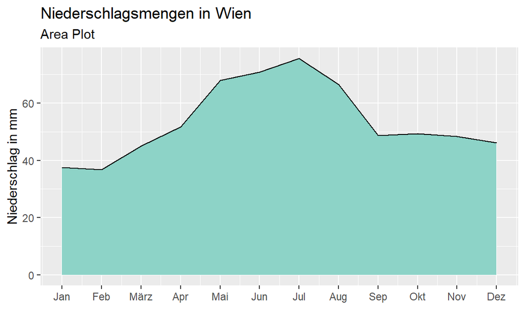

```r
ggplot(daten, aes(x=months, y= Wien )) +
  geom_area(color="black", fill=myPalette[1]) +
  scale_x_continuous(breaks=1:12,
                     labels=myMonths) +
  labs(
         title="Niederschlagsmengen in Wien",
         subtitle = "Area Plot",
         x = " ",
         y="Niederschlag in mm"
  )

ggsave(filename="timeWienArea.png", plot=last_plot(),
       device="png",
       path="images/",
       width=16, height=9, units="cm")
```

Eine weitere Möglichkeit ist die Verwendung eines Zeit-Histogramms. Dazu verwenden wir *geom_bar* in der Darstellung. Da für ein Histogramm in diesem Geom als Default Klassen gebildet werden und wir dies hier abschalten möchten übergeben wir die Option *stat=“identity”*.

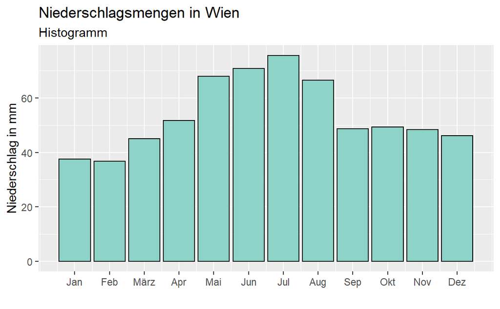

```r
ggplot(daten, aes(x=months, y= Wien )) +
  geom_bar(color="black", fill=myPalette[1], stat="identity") +
  scale_x_continuous(breaks=1:12,
                     labels=myMonths) +
  labs(
         title="Niederschlagsmengen in Wien",
         subtitle = "Histogramm",
         x = " ",
         y="Niederschlag in mm"
  )

ggsave(filename="timeWienHisto.png", plot=last_plot(),
       device="png",
       path="images/",
       width=16, height=9, units="cm")
```

Sehr häufig werden in Zeitreihen Trendlinien berechnet und visualisiert. Dazu fügen wir die Funktion *stat_smooth* hinzu. Für eine bessere Darstellung stellen wir die Zeitreihe als Punkte dar. Wenn wir die Option weglassen wird ein Konfidenzintervall um die Trendlinie dargestellt, die uns anzeigt in welchen Intervall die Trendlinie mit 95% Wahrscheinlichkeit liegt. Dieses Signifikanzniveau können wir ebenfalls beim Aufruf verändern.

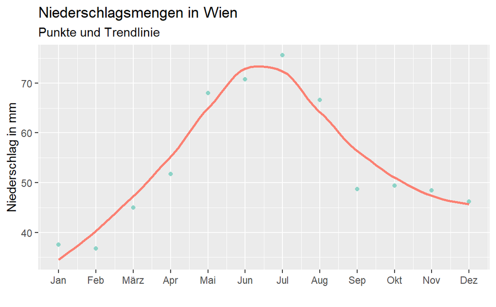

```r
ggplot(daten, aes(x=months, y=Wien)) +
  geom_point(color=myPalette[1]) +
  stat_smooth(color=myPalette[4], se=FALSE) +
  scale_x_continuous(breaks=1:12,
                     labels=myMonths) +
  labs(
         title="Niederschlagsmengen in Wien",
         subtitle = "Punkte und Trendlinie",
         x = " ",
         y="Niederschlag in mm"
  )
ggsave(filename="timeWien.png", plot=last_plot(),
       device="png",
       path="images/",
       width=16, height=9, units="cm")
```

# 3 Literaturverzeichnis

Benesch, Thomas. 2013. *Schlüsselkonzepte Zur Statistik*. Springer Spektrum.